# Week 13 – Time to event data lab

Drew Tyre

November 12, 2016

In this weeks lab you’ll explore a dataset collected by Mitch Bern on the attack behavior of spiders. Each spider was placed in an arena with a prey item (cricket) that was either tasty or not tasty, and provided with cues (vibration or no vibration). This trial was repeated for each individual 9 times. The question is whether or not the presence of an unrelated cue (the vibration) speeds up learning. The response is latency to attack measured in seconds; trials were terminated at 900 seconds so there are censored observations.

```r
library(tidyverse)
```

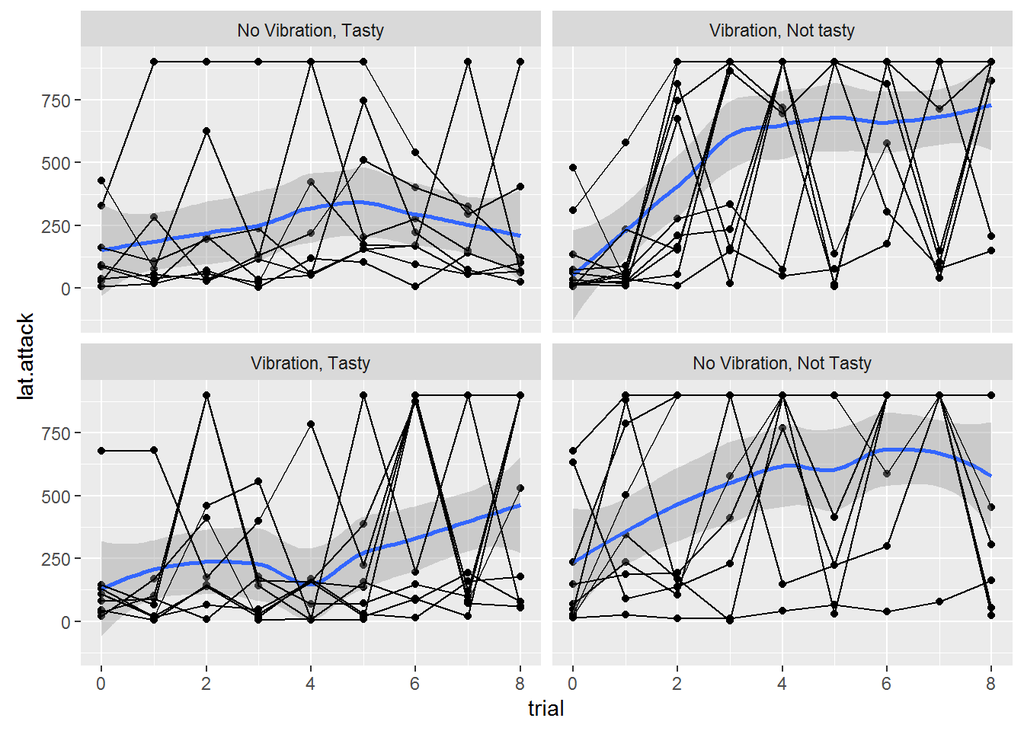

Attack latency in seconds across trials by treatment. Thin black lines join points representing the same spider. There is quite a lot of overplotting. Smooth curves show expected latency by trial assuming censored individuals attack at 900 seconds.

```r
spiders <- read.csv("data/Spider.csv")

trt.longnames <- c(Blue = "No Vibration, Tasty", Orange = "Vibration, Not tasty",
    Purple = "Vibration, Tasty", Yellow = "No Vibration, Not Tasty")
ggplot(spiders, aes(x = trial, y = lat.attack)) + geom_point() + geom_smooth() +
    facet_wrap(~treatment, labeller = labeller(treatment = trt.longnames)) +
    geom_line(aes(group = animal))
```

As you can see in the scatterplots, spiders in the Not Tasty treatments do take longer to attack the prey as trials progress. However there is alot of variation among individual spiders. Some spiders offered tasty prey simply didn’t attack for several trials, and another spider in the no vibration not tasty treatment always attacked quickly! Behavioral ecologists worry alot about anthropomorphizing, so to avoid this potential bias Mitch called the treatments Blue, Purple, Yellow and Orange. This is fine, but makes it a bit hard to test for interactions between the two seperate experimental factors. The statistical version of Mitch’s hypothesis is an interaction between trial and treatment. You can see the correspondence between the colors and the experimental treatments using the variable “vd”:

```r
with(spiders, table(treatment, vd))
```

```
##          vd
## treatment nn ny yn yy
##    Blue   72  0  0  0
##    Orange  0  0  0 99
##    Purple  0  0 81  0
##    Yellow  0 81  0  0
```

The first letter is y/n for vibration, and the second is y/n for distastful (so ‘y’ is not tasty).

1. Thinking about mean latency to attack in our regular lm() framework, how would mean latency change with a distasteful by vibration interaction? Think about trial 0 compared to trial 8 in each treatment.

> In trial 0 there should be no differences between the treatments, because all spiders have no experience with different types of prey. By trial 8, latency to attack should be greater in treatments with distasteful prey, while there should be no change in treatments with tasty prey. If the extra vibration signal increases learning rate, latency to attack will be even longer or longer at earlier trials when both vibration and distasteful prey are present.
2. Use lm() to fit the model lat.attack ~ distasteful * vibration * trial model. Check the residuals. Does the mean latency change as you expected? Is there a significant interaction?

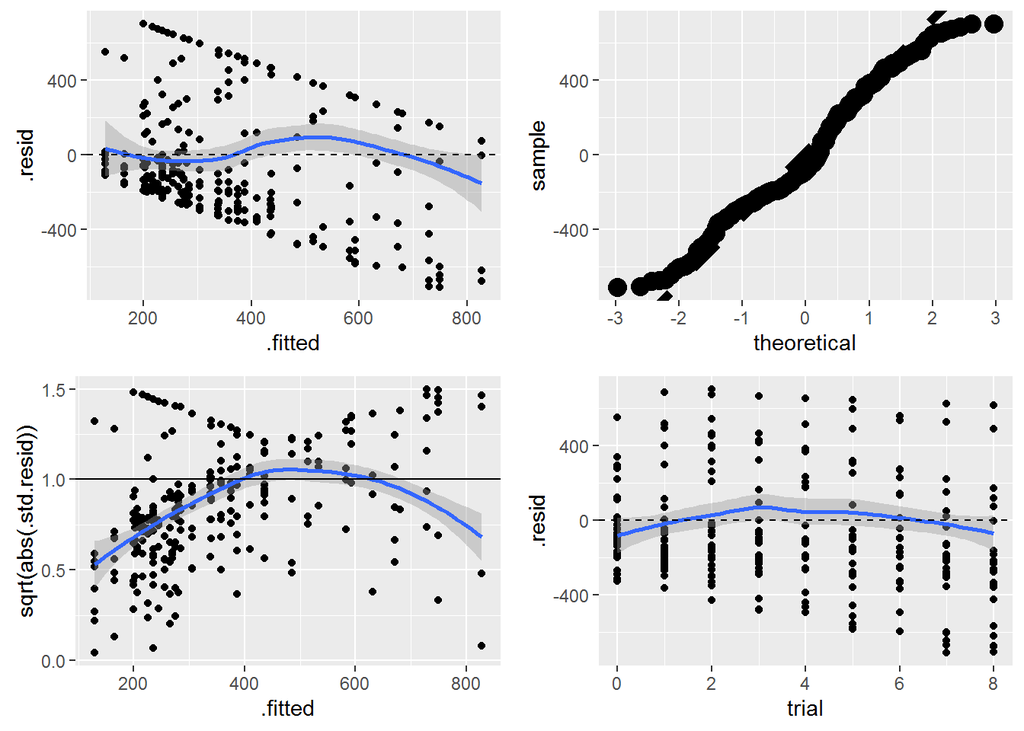

```r
globallm <- lm(lat.attack ~ distasteful * vibration * trial, data = spiders)
rr <- broom::augment(globallm)
rr1 <- ggplot(rr, aes(x = .fitted, y = .resid)) + geom_point() + geom_smooth() +
    geom_hline(yintercept = 0, linetype = 2)

# get int and slope for qqline
probs <- c(0.25, 0.75)
y <- quantile(rr$.resid, probs, names = FALSE, na.rm = TRUE)
x <- qnorm(probs)
slope <- diff(y)/diff(x)
int <- y[1L] - slope * x[1L]
rr2 <- ggplot(rr, aes(sample = .resid)) + geom_qq(size = rel(4)) + geom_abline(intercept = int,
    slope = slope, linetype = 2, size = 2)

rr3 <- ggplot(rr, aes(x = .fitted, y = sqrt(abs(.std.resid)))) + geom_point() +
    geom_smooth() + geom_hline(yintercept = 1)

rr4 <- ggplot(rr, aes(x = trial, y = .resid)) + geom_point() + geom_smooth() +
    geom_hline(yintercept = 0, linetype = 2)

# the :: means I don't have to do library(gridExtra) to get at the function
# -- handy if I only want it once.
gridExtra::grid.arrange(rr1, rr2, rr3, rr4)
```

> Bwahahahaha! Well, if those residual plots don’t make you stop and think about what you’re doing, I’ve not done my job properly! But, let’s see what simplifying the model tells us.

```r
drop1(globallm, test = "F")
```

```
## Single term deletions
##
## Model:
## lat.attack ~ distasteful * vibration * trial
##                             Df Sum of Sq      RSS    AIC F value Pr(>F)
## <none>                                   33624977 3853.0
## distasteful:vibration:trial  1    2327.1 33627304 3851.1  0.0225 0.8809
```

```r
# OK I can remove the 3 way interaction that means vibration DOES NOT affect
# learning rate
m1 <- update(globallm, . ~ . - distasteful:vibration:trial)
drop1(m1, test = "F")
```

```
## Single term deletions
##
## Model:
## lat.attack ~ distasteful + vibration + trial + distasteful:vibration +
##     distasteful:trial + vibration:trial
##                       Df Sum of Sq      RSS    AIC F value   Pr(>F)
## <none>                             33627304 3851.1
## distasteful:vibration  1     38981 33666285 3849.4  0.3779 0.539158
## distasteful:trial      1    937245 34564549 3858.2  9.0861 0.002778 **
## vibration:trial        1    414533 34041837 3853.1  4.0187 0.045825 *
## ---
## Signif. codes:  0 '***' 0.001 '**' 0.01 '*' 0.05 '.' 0.1 ' ' 1
```

```r
# I can remove the distasteful by vibration interaction
m2 <- update(m1, . ~ . - distasteful:vibration)
drop1(m2, test = "F")  # can't remove anything else
```

```
## Single term deletions
##
## Model:
## lat.attack ~ distasteful + vibration + trial + distasteful:trial +
##     vibration:trial
##                   Df Sum of Sq      RSS    AIC F value   Pr(>F)
## <none>                         33666285 3849.4
## distasteful:trial  1    937245 34603530 3856.6  9.1034 0.002751 **
## vibration:trial    1    414533 34080818 3851.5  4.0264 0.045618 *
## ---
## Signif. codes:  0 '***' 0.001 '**' 0.01 '*' 0.05 '.' 0.1 ' ' 1
```

```r
summary(m2)
```

```
##
## Call:
## lm(formula = lat.attack ~ distasteful + vibration + trial + distasteful:trial +
##     vibration:trial, data = spiders)
##
## Residuals:
##     Min      1Q  Median      3Q     Max
## -715.42 -223.75  -79.35  264.92  713.49
##
## Coefficients:
##                   Estimate Std. Error t value Pr(>|t|)
## (Intercept)        223.163     58.947   3.786 0.000182 ***
## distasteful         99.840     65.072   1.534 0.125924
## vibration         -108.810     65.072  -1.672 0.095454 .
## trial                8.653     12.381   0.699 0.485120
## distasteful:trial   41.239     13.668   3.017 0.002751 **
## vibration:trial     27.426     13.668   2.007 0.045618 *
## ---
## Signif. codes:  0 '***' 0.001 '**' 0.01 '*' 0.05 '.' 0.1 ' ' 1
##
## Residual standard error: 320.9 on 327 degrees of freedom
## Multiple R-squared:   0.26,  Adjusted R-squared:  0.2487
## F-statistic: 22.98 on 5 and 327 DF,  p-value: < 2.2e-16
```

> So the experiment isn’t a total loss. Average Latency at trial 0 in the nn treatment is 223 seconds, and the increase of 8.7 seconds with each additional trial is not significant, as expected. Experiencing distasteful prey increases latency to attack by 41 seconds with each additional trial. Experiencing vibration also increases latency to attack by 27 seconds with each additional trial, a smaller amount than experiencing distasteful prey. The effects of distasteful prey and vibration are additive. That is, there is no evidence that learning is faster in the presence of multiple cues. Note that using the treatment variable instead of distasteful*vibration makes it much harder to reach this conclusion. In addition, if censored observations are removed instead of being treated as event at 900 seconds, the entire model is not significant.

So the first thing to do is to get some survival curves. We’ve actually got a repeated measures or mixed effects situation here with individuals representing our groups, but we’ll ignore that for the moment. The variable ``att’’ is 0 if the spider didn’t attack, and 1 if it did - so it acts as a censoring indicator.

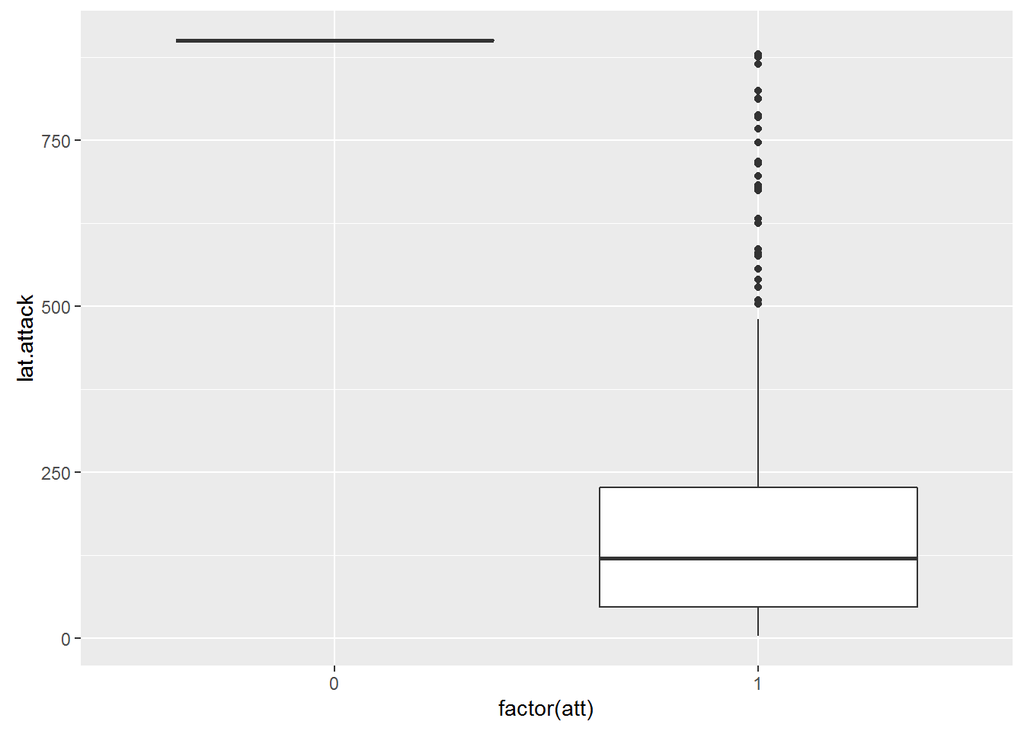

```r
ggplot(spiders, aes(x = factor(att), y = lat.attack)) + geom_boxplot()
```

All the individuals with att == 0 had latencies of 900 seconds; they never attacked. We start survival analysis by calculating Kaplan-Meier survivorship curves.

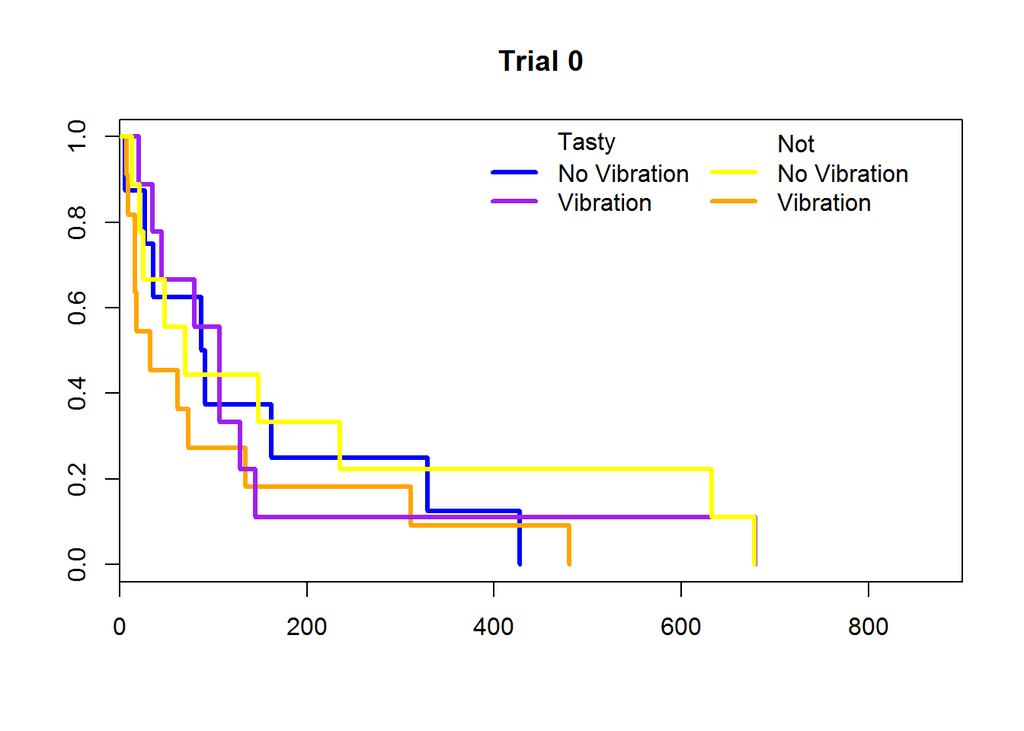

```r
library(survival)
# On the LHS of formula the response is a Surv() object the first argument
# is the time of the event the second argument is the censoring indicator 1
# if the event occurred, or 0 if the observation is censored at that point
# only use the trial 0 data
spiders.km0 <- survfit(Surv(lat.attack, att) ~ treatment, data = spiders[spiders$trial ==
    0, ])

# there is a plot() method for these objects
plot(spiders.km0, col = c("Blue", "Orange", "Purple", "Yellow"), lwd = 3, main = "Trial 0",
    xlim = c(0, 900))
# manually add a legend, base graphics style
loc <- legend("topright", legend = rep(c("No Vibration", "Vibration"), times = 2),
    lwd = 3, col = c("Blue", "Purple", "Yellow", "Orange"), bty = "n", ncol = 2,
    xjust = 0.5, inset = 0.05)
# use the return value of legend() to figure out where the columns are
ypos = 2 * loc$text$y[1] - loc$text$y[2]
# Add the Tasty not Tasty above the columns
text(loc$text$x[c(1, 3)], ypos, labels = c("Tasty", "Not"), adj = 0)
```

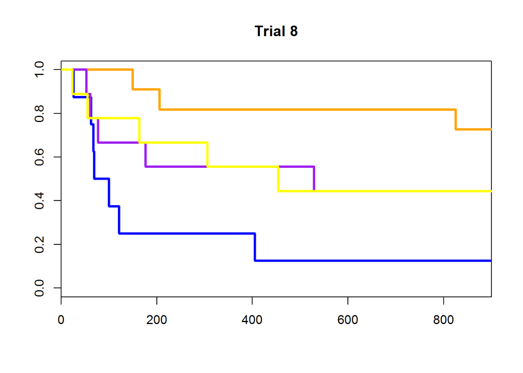

```r
# do it for trial 8
spiders.km8 = survfit(Surv(lat.attack, att) ~ treatment, data = spiders[spiders$trial ==
    8, ])
plot(spiders.km8, col = c("Blue", "Orange", "Purple", "Yellow"), lwd = 3, main = "Trial 8",
    xlim = c(0, 900))
```

As we might expect, it looks like there are no differences between treatments on the first trial, while on the 8th trial there are substantial differences. These differences were undetectable until the censored trials were properly accounted for.

Automatic plot methods are nice, but I want to see what ggplot2 can do for us here. I’ll refit the survfit objects with both trial and treatment, use broom::tidy(), and then ggplot().

```r
spiders.kmall <- survfit(Surv(lat.attack, att) ~ treatment + trial, data = spiders)
spiders.tdy <- broom::tidy(spiders.kmall)
head(spiders.tdy)  # hmm, augment has wrapped up the
```

```
##   time n.risk n.event n.censor estimate std.error conf.high   conf.low
## 1    6      8       1        0    0.875 0.1336306 1.0000000 0.67338194
## 2   27      7       1        0    0.750 0.2041241 1.0000000 0.50270184
## 3   36      6       1        0    0.625 0.2738613 1.0000000 0.36540028
## 4   87      5       1        0    0.500 0.3535534 0.9998048 0.25004882
## 5   91      4       1        0    0.375 0.4564355 0.9173812 0.15328960
## 6  162      3       1        0    0.250 0.6123724 0.8302184 0.07528139
##                    strata
## 1 treatment=Blue, trial=0
## 2 treatment=Blue, trial=0
## 3 treatment=Blue, trial=0
## 4 treatment=Blue, trial=0
## 5 treatment=Blue, trial=0
## 6 treatment=Blue, trial=0
```

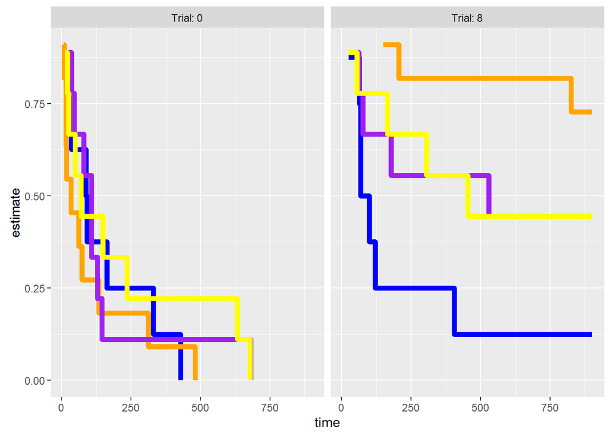

```r
# variables treatment and trial into a thing called strata. I need them
# broken out.
spiders.tdy <- separate(spiders.tdy, strata, into = c("t1", "Treatment", "t2",
    "Trial"))
# I don't care about columns t1 and t2

filter(spiders.tdy, Trial %in% c(0, 8)) %>% ggplot(aes(x = time, y = estimate)) +
    geom_step(aes(col = Treatment), size = 2) + scale_color_manual(values = c(Blue = "blue",
    Orange = "orange", Purple = "purple", Yellow = "yellow")) + facet_wrap(~Trial,
    labeller = label_both) + guides(color = FALSE)
```

So lets try a Cox proportional hazards model with trial and treatment as covariates. A cox model assumes that the variables are simply multiplying the baseline hazard. I will set Individual as a *cluster* variable - equivalent to specifying a random effect in a mixed effects model. In a Cox model this estimates a different baseline hazard function for each individual.

```r
spiders.ph1 <- coxph(Surv(lat.attack, att) ~ treatment * trial + cluster(animal),
    data = spiders)
summary(spiders.ph1)
```

```
## Call:
## coxph(formula = Surv(lat.attack, att) ~ treatment * trial + cluster(animal),
##     data = spiders)
##
##   n= 333, number of events= 235
##
##                           coef exp(coef) se(coef) robust se      z
## treatmentOrange        0.36974   1.44735  0.32880   0.44025  0.840
## treatmentPurple        0.33637   1.39985  0.31762   0.44142  0.762
## treatmentYellow       -0.26131   0.77004  0.34342   0.47314 -0.552
## trial                 -0.04653   0.95453  0.05153   0.04003 -1.163
## treatmentOrange:trial -0.32937   0.71938  0.08140   0.07396 -4.453
## treatmentPurple:trial -0.09360   0.91064  0.06958   0.05647 -1.658
## treatmentYellow:trial -0.19474   0.82305  0.08236   0.08485 -2.295
##                       Pr(>|z|)
## treatmentOrange         0.4010
## treatmentPurple         0.4461
## treatmentYellow         0.5808
## trial                   0.2450
## treatmentOrange:trial 8.46e-06 ***
## treatmentPurple:trial   0.0974 .
## treatmentYellow:trial   0.0217 *
## ---
## Signif. codes:  0 '***' 0.001 '**' 0.01 '*' 0.05 '.' 0.1 ' ' 1
##
##                       exp(coef) exp(-coef) lower .95 upper .95
## treatmentOrange          1.4474     0.6909    0.6107    3.4301
## treatmentPurple          1.3999     0.7144    0.5893    3.3252
## treatmentYellow          0.7700     1.2986    0.3046    1.9465
## trial                    0.9545     1.0476    0.8825    1.0324
## treatmentOrange:trial    0.7194     1.3901    0.6223    0.8316
## treatmentPurple:trial    0.9106     1.0981    0.8152    1.0172
## treatmentYellow:trial    0.8231     1.2150    0.6970    0.9720
##
## Concordance= 0.692  (se = 0.02 )
## Rsquare= 0.272   (max possible= 0.999 )
## Likelihood ratio test= 105.6  on 7 df,   p=0
## Wald test            = 57.27  on 7 df,   p=5.29e-10
## Score (logrank) test = 95.76  on 7 df,   p=0,   Robust = 27.06  p=0.0003254
##
##   (Note: the likelihood ratio and score tests assume independence of
##      observations within a cluster, the Wald and robust score tests do not).
```

So compared to Blue, treatments Orange and Yellow have reduced hazards (negative coefficients) with increasing trial. Orange and Yellow treatments have distasteful prey, and Orange has both vibration and distasteful prey. Treatment Purple (vibration only) also has a reduced hazard with increasing trial but the coefficient is not significantly different from zero.

It is difficult to directly interpret the coefficients in the summary table. The columns labelled `exp(coef)` can be interpreted as the proportional change in the baseline hazard. So, the baseline hazard drops by ~5% (0.95) for each additional trial in the Blue treatment, but the confidence limits on that number include 1 (no change in hazard). Treatment Orange looks like a 45% increase in hazard at trial 0, but again the confidence limits include zero. Individuals in the orange treatment have a hazard reducing by 28% with each additional trial, and the confidence limits there do not include zero.

Before we get too carried away interpreting this model we need to check the assumptions using complementary log-log plots and log survival plots. To do this we can either use the survfit objects we created above, or make some new ones from the fitted Cox model. We can also use cox.zph() function to get a test from the model itself. Remember the lines should be straight and parallel on the complementary log-log plot for the proportional hazards assumption, and straight and parallel on the cumulative hazard plot for accelerated failure time. I’m a bit lazy so I will use the builtin plot method for survfit objects.

```r
cox.zph(spiders.ph1)  # looks OK
```

```
##                           rho chisq     p
## treatmentOrange       -0.0607 2.698 0.100
## treatmentPurple       -0.0308 0.717 0.397
## treatmentYellow       -0.0243 0.440 0.507
## trial                 -0.0197 0.190 0.663
## treatmentOrange:trial  0.0576 1.177 0.278
## treatmentPurple:trial -0.0152 0.077 0.781
## treatmentYellow:trial -0.0335 0.512 0.474
## GLOBAL                     NA 6.047 0.534
```

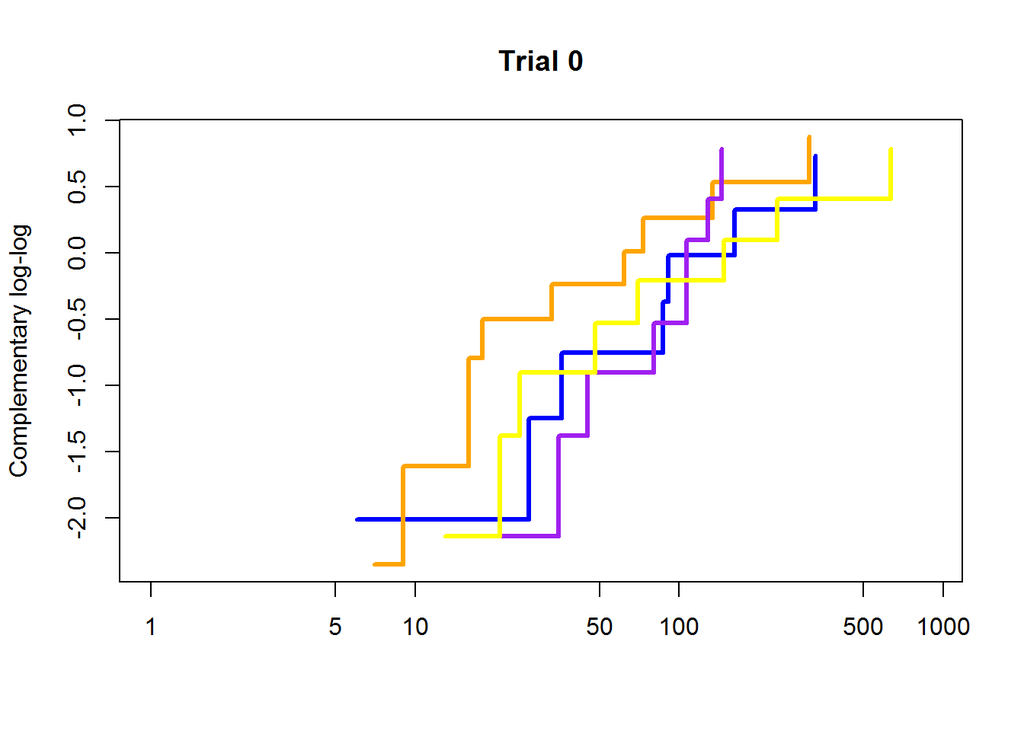

```r
plot(spiders.km0, fun = "cloglog", col = c("Blue", "Orange", "Purple", "Yellow"),
    lwd = 3, main = "Trial 0", xlim = c(1, 900), ylab = "Complementary log-log")
```

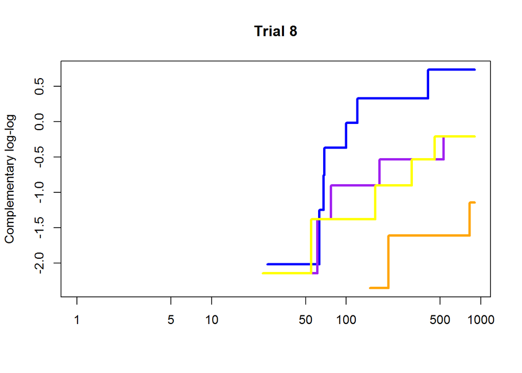

```r
plot(spiders.km8, fun = "cloglog", col = c("Blue", "Orange", "Purple", "Yellow"),
    lwd = 3, main = "Trial 8", xlim = c(1, 900), ylab = "Complementary log-log")
```

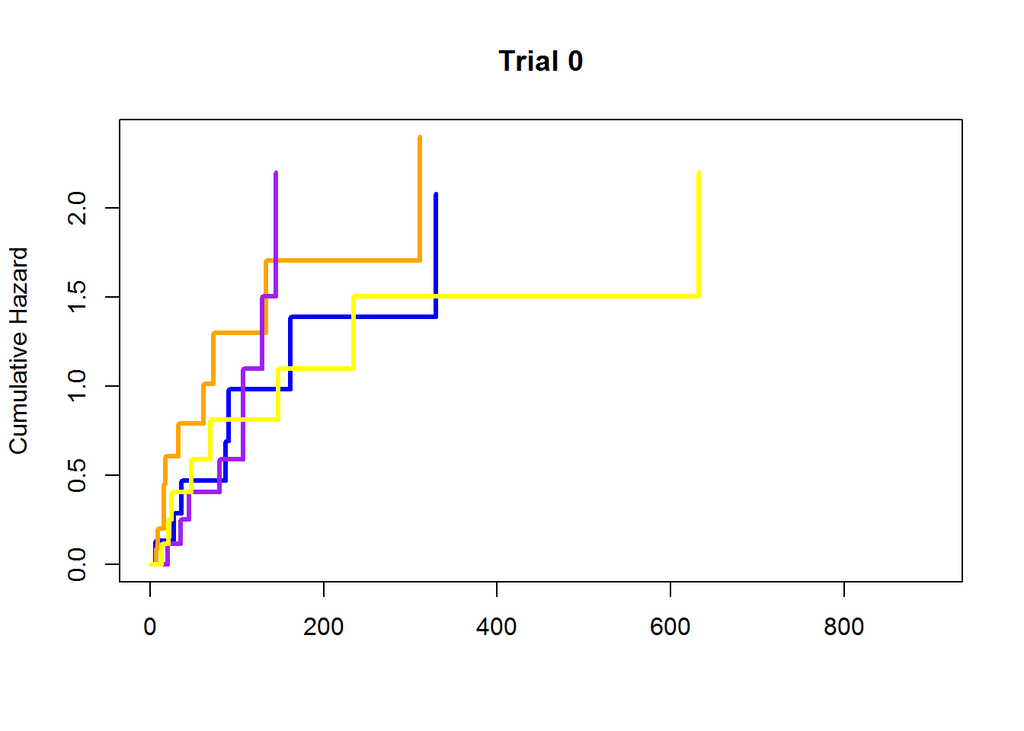

```r
plot(spiders.km0, fun = "cumhaz", col = c("Blue", "Orange", "Purple", "Yellow"),
    lwd = 3, main = "Trial 0", xlim = c(1, 900), ylab = "Cumulative Hazard")
```

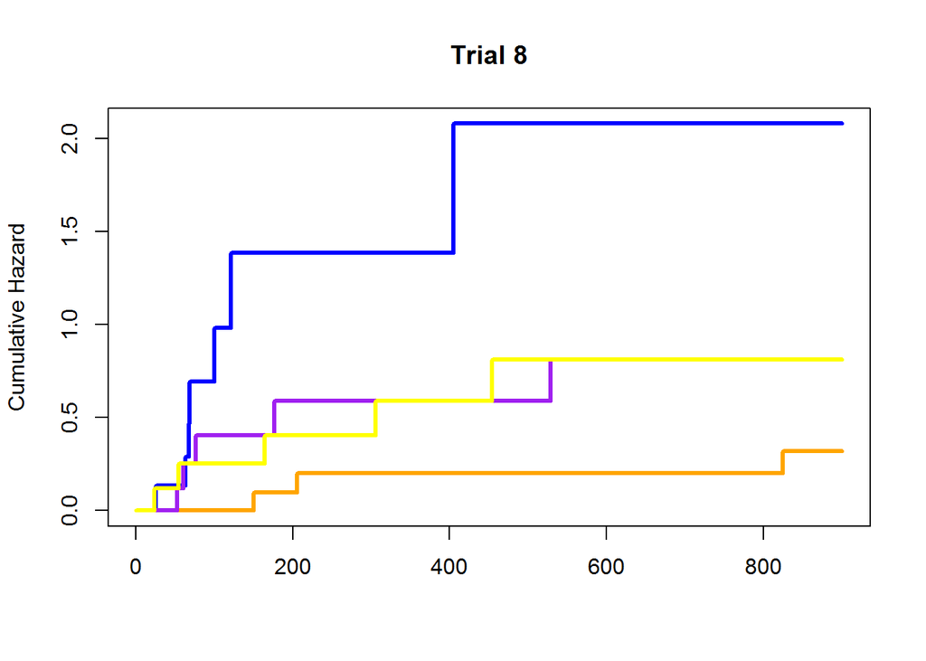

```r
plot(spiders.km8, fun = "cumhaz", col = c("Blue", "Orange", "Purple", "Yellow"),
    lwd = 3, main = "Trial 8", xlim = c(1, 900), ylab = "Cumulative Hazard")
```

So this is all good - we can’t use accelerated failure time, and the proportional hazards assumption looks OK.

Can we simplify this model? This is a designed experiment, so we can do backwards selection.

```r
drop1(spiders.ph1, test = "Chisq")
```

```
## Single term deletions
##
## Model:
## Surv(lat.attack, att) ~ treatment * trial + cluster(animal)
##                 Df    AIC    LRT  Pr(>Chi)
## <none>             2409.2
## cluster(animal)  0 2409.2  0.000
## treatment:trial  3 2421.9 18.688 0.0003172 ***
## ---
## Signif. codes:  0 '***' 0.001 '**' 0.01 '*' 0.05 '.' 0.1 ' ' 1
```

3. Can we simplify this model? If so, continue with backwards selection until you have the simplest model.

> We cannot simplify this model because removing the treatment by trial interaction changes the likelihood by an amount that is very unlikely to occur by chance (p < 0.001) if the interaction was not important.

I will use model spider.ph1 to make some predictions for Trial 8.

```r
foobar = data.frame(trial = 8, treatment = factor(c("Blue", "Orange", "Purple",
    "Yellow")))
# predict() doesn't work here, nor augment.  use survfit with fitted object
# and newdata
spiders.pred = survfit(spiders.ph1, newdata = foobar)
str(spiders.pred)  # see what everything is called in the object
```

```
## List of 14
##  $ n        : int 333
##  $ time     : num [1:175] 3 5 6 7 8 9 10 11 12 13 ...
##  $ n.risk   : num [1:175] 333 332 328 327 324 323 319 317 316 315 ...
##  $ n.event  : num [1:175] 1 4 1 3 1 4 2 1 1 1 ...
##  $ n.censor : num [1:175] 0 0 0 0 0 0 0 0 0 0 ...
##  $ surv     : num [1:175, 1:4] 0.997 0.983 0.98 0.97 0.967 ...
##   ..- attr(*, "dimnames")=List of 2
##   .. ..$ : NULL
##   .. ..$ : chr [1:4] "1" "2" "3" "4"
##  $ type     : chr "right"
##  $ cumhaz   : num [1:175, 1:4] 0.00333 0.01676 0.02016 0.03046 0.03393 ...
##  $ std.err  : num [1:175, 1:4] 0.00337 0.00798 0.00887 0.01131 0.01208 ...
##  $ upper    : num [1:175, 1:4] 1 0.999 0.997 0.992 0.99 ...
##   ..- attr(*, "dimnames")=List of 2
##   .. ..$ : NULL
##   .. ..$ : chr [1:4] "1" "2" "3" "4"
##  $ lower    : num [1:175, 1:4] 0.99 0.968 0.963 0.949 0.944 ...
##   ..- attr(*, "dimnames")=List of 2
##   .. ..$ : NULL
##   .. ..$ : chr [1:4] "1" "2" "3" "4"
##  $ conf.type: chr "log"
##  $ conf.int : num 0.95
##  $ call     : language survfit(formula = spiders.ph1, newdata = foobar)
##  - attr(*, "class")= chr [1:2] "survfit.cox" "survfit"
```

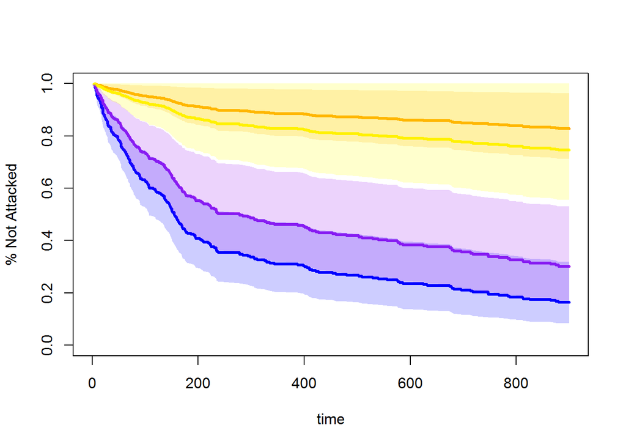

```r
# boy that's ugly -- have to piece everything together by hand ... here's
# the old way to do that manually put together a plot make some transparent
# colors to match
my.colors <- col2rgb(c("Blue", "Orange", "Purple", "Yellow"))
my.colors <- rgb(my.colors[1, ], my.colors[2, ], my.colors[3, ], alpha = 50,
    max = 255)
with(spiders.pred, plot(time, surv[, 1], xlim = c(0, 900), ylim = c(0, 1), col = "Blue",
    lwd = 3, type = "s", ylab = "% Not Attacked"))
with(spiders.pred, lines(time, surv[, 2], col = "Orange", lwd = 3, type = "s"))
with(spiders.pred, lines(time, surv[, 3], col = "Purple", lwd = 3, type = "s"))
with(spiders.pred, lines(time, surv[, 4], col = "Yellow", lwd = 3, type = "s"))
with(spiders.pred, polygon(c(time, rev(time)), c(lower[, 1], rev(upper[, 1])),
    col = my.colors[1], border = NA))
with(spiders.pred, polygon(c(time, rev(time)), c(lower[, 2], rev(upper[, 2])),
    col = my.colors[2], border = NA))
with(spiders.pred, polygon(c(time, rev(time)), c(lower[, 3], rev(upper[, 3])),
    col = my.colors[3], border = NA))
with(spiders.pred, polygon(c(time, rev(time)), c(lower[, 4], rev(upper[, 4])),
    col = my.colors[4], border = NA))
```

That’s a nice plot, but what a lot of work! Making prediction plots from survival objects remains a difficult task.

If you look at the plots of latency in trial 8, it looks like vibration on its own deters attack (purple higher than blue) although the confidence levels nearly include the other curve. In addition, there doesn’t seem to be any difference between the curves for Orange and Yellow (distasteful prey), because the confidence levels overlap widely. So perhaps there’s no interaction between vibration and non-tasty prey - maybe they are just adding together to deter attack. This plot looks quite different from the Survivorship plot constructed above, where Orange had quite a bit larger survival. The difference could be due to treating trial as a linear covariate in the Cox model.

4. Try a different Cox model using a three way interaction between variables `vibration`, `distasteful`, and `trial` to test this idea. Simplify it as far as possible using backwards selection. Does this improve your ability to test the biological hypothesis?

```r
spider.ph2 <- coxph(Surv(lat.attack, att) ~ vibration * distasteful * trial +
    cluster(animal), data = spiders)
drop1(spider.ph2, test = "Chisq")
```

```
## Single term deletions
##
## Model:
## Surv(lat.attack, att) ~ vibration * distasteful * trial + cluster(animal)
##                             Df    AIC     LRT Pr(>Chi)
## <none>                         2409.2
## cluster(animal)              0 2409.2 0.00000
## vibration:distasteful:trial  1 2407.4 0.13107   0.7173
```

```r
# can drop 3 way interaction
spider.ph3 <- update(spider.ph2, . ~ . - vibration:distasteful:trial)
drop1(spider.ph3, test = "Chisq")
```

```
## Single term deletions
##
## Model:
## Surv(lat.attack, att) ~ vibration + distasteful + trial + cluster(animal) +
##     vibration:distasteful + vibration:trial + distasteful:trial
##                       Df    AIC     LRT  Pr(>Chi)
## <none>                   2407.4
## cluster(animal)        0 2407.4  0.0000
## vibration:distasteful  1 2405.7  0.3515 0.5532659
## vibration:trial        1 2409.3  3.9285 0.0474751 *
## distasteful:trial      1 2420.3 14.9117 0.0001127 ***
## ---
## Signif. codes:  0 '***' 0.001 '**' 0.01 '*' 0.05 '.' 0.1 ' ' 1
```

```r
# can drop vibration:distasteful
spider.ph4 <- update(spider.ph3, . ~ . - vibration:distasteful)
drop1(spider.ph4, test = "Chisq")
```

```
## Single term deletions
##
## Model:
## Surv(lat.attack, att) ~ vibration + distasteful + trial + cluster(animal) +
##     vibration:trial + distasteful:trial
##                   Df    AIC     LRT  Pr(>Chi)
## <none>               2405.7
## cluster(animal)    0 2405.7  0.0000
## vibration:trial    1 2408.2  4.4766   0.03436 *
## distasteful:trial  1 2418.9 15.1415 9.975e-05 ***
## ---
## Signif. codes:  0 '***' 0.001 '**' 0.01 '*' 0.05 '.' 0.1 ' ' 1
```

```r
# can't drop anything else
summary(spider.ph4)
```

```
## Call:
## coxph(formula = Surv(lat.attack, att) ~ vibration + distasteful +
##     trial + cluster(animal) + vibration:trial + distasteful:trial,
##     data = spiders)
##
##   n= 333, number of events= 235
##
##                       coef exp(coef) se(coef) robust se      z Pr(>|z|)
## vibration          0.48440   1.62320  0.22926   0.28242  1.715 0.086312
## distasteful       -0.09541   0.90900  0.22908   0.27671 -0.345 0.730234
## trial             -0.03366   0.96690  0.04589   0.03526 -0.955 0.339762
## vibration:trial   -0.11473   0.89160  0.05427   0.04547 -2.523 0.011625
## distasteful:trial -0.21793   0.80418  0.05669   0.05811 -3.750 0.000177
##
## vibration         .
## distasteful
## trial
## vibration:trial   *
## distasteful:trial ***
## ---
## Signif. codes:  0 '***' 0.001 '**' 0.01 '*' 0.05 '.' 0.1 ' ' 1
##
##                   exp(coef) exp(-coef) lower .95 upper .95
## vibration            1.6232     0.6161    0.9332    2.8233
## distasteful          0.9090     1.1001    0.5285    1.5635
## trial                0.9669     1.0342    0.9023    1.0361
## vibration:trial      0.8916     1.1216    0.8156    0.9747
## distasteful:trial    0.8042     1.2435    0.7176    0.9012
##
## Concordance= 0.693  (se = 0.02 )
## Rsquare= 0.271   (max possible= 0.999 )
## Likelihood ratio test= 105.1  on 5 df,   p=0
## Wald test            = 56.34  on 5 df,   p=6.921e-11
## Score (logrank) test = 95.23  on 5 df,   p=0,   Robust = 26.6  p=6.837e-05
##
##   (Note: the likelihood ratio and score tests assume independence of
##      observations within a cluster, the Wald and robust score tests do not).
```

> So we loose the three way interaction and the distasteful by vibration interaction. There is no magnification of learning by including multiple cues. This is the same conclusion we came to with the lm() model, although our estimates of expected time to attack will be unbiased here. Getting the structure of the predictor variables correct is more important to reaching the right conclusion than treating the response variable correctly.

```r
# just for kicks, try with trial as a factor
spider.ph5 <- coxph(Surv(lat.attack, att) ~ vibration * distasteful * factor(trial) +
    cluster(animal), data = spiders)
drop1(spider.ph5, test = "Chisq")
```

```
## Single term deletions
##
## Model:
## Surv(lat.attack, att) ~ vibration * distasteful * factor(trial) +
##     cluster(animal)
##                                     Df    AIC    LRT Pr(>Chi)
## <none>                                 2432.0
## cluster(animal)                      0 2432.0 0.0000
## vibration:distasteful:factor(trial)  8 2422.5 6.4681    0.595
```

```r
# can drop 3 way interaction
spider.ph6 <- update(spider.ph5, . ~ . - vibration:distasteful:factor(trial))
drop1(spider.ph6, test = "Chisq")
```

```
## Single term deletions
##
## Model:
## Surv(lat.attack, att) ~ vibration + distasteful + factor(trial) +
##     cluster(animal) + vibration:distasteful + vibration:factor(trial) +
##     distasteful:factor(trial)
##                           Df    AIC     LRT Pr(>Chi)
## <none>                       2422.5
## cluster(animal)            0 2422.5  0.0000
## vibration:distasteful      1 2421.3  0.8276 0.362979
## vibration:factor(trial)    8 2420.8 14.2719 0.074947 .
## distasteful:factor(trial)  8 2430.4 23.8991 0.002383 **
## ---
## Signif. codes:  0 '***' 0.001 '**' 0.01 '*' 0.05 '.' 0.1 ' ' 1
```

```r
# can drop vibration:distasteful
spider.ph7 <- update(spider.ph6, . ~ . - vibration:distasteful)
drop1(spider.ph7, test = "Chisq")
```

```
## Single term deletions
##
## Model:
## Surv(lat.attack, att) ~ vibration + distasteful + factor(trial) +
##     cluster(animal) + vibration:factor(trial) + distasteful:factor(trial)
##                           Df    AIC    LRT Pr(>Chi)
## <none>                       2421.3
## cluster(animal)            0 2421.3  0.000
## vibration:factor(trial)    8 2419.9 14.600 0.067412 .
## distasteful:factor(trial)  8 2429.1 23.776 0.002499 **
## ---
## Signif. codes:  0 '***' 0.001 '**' 0.01 '*' 0.05 '.' 0.1 ' ' 1
```

```r
# interaction of vibration with trial now borderline, but keep it
summary(spider.ph7)
```

```
## Call:
## coxph(formula = Surv(lat.attack, att) ~ vibration + distasteful +
##     factor(trial) + cluster(animal) + vibration:factor(trial) +
##     distasteful:factor(trial), data = spiders)
##
##   n= 333, number of events= 235
##
##                                coef exp(coef) se(coef) robust se      z
## vibration                   0.30582   1.35773  0.33164   0.31892  0.959
## distasteful                 0.11034   1.11666  0.33162   0.31071  0.355
## factor(trial)1             -0.30062   0.74036  0.46181   0.34608 -0.869
## factor(trial)2             -0.45285   0.63581  0.45984   0.26868 -1.685
## factor(trial)3             -0.03987   0.96091  0.45026   0.32117 -0.124
## factor(trial)4             -0.54054   0.58243  0.47050   0.30894 -1.750
## factor(trial)5             -0.48940   0.61299  0.44434   0.34689 -1.411
## factor(trial)6             -0.39626   0.67283  0.46246   0.25197 -1.573
## factor(trial)7             -0.61316   0.54163  0.49713   0.39487 -1.553
## factor(trial)8             -0.17551   0.83903  0.46619   0.30806 -0.570
## vibration:factor(trial)1    0.54287   1.72095  0.48033   0.35521  1.528
## vibration:factor(trial)2   -0.43525   0.64710  0.49977   0.40526 -1.074
## vibration:factor(trial)3   -0.25073   0.77823  0.51052   0.37515 -0.668
## vibration:factor(trial)4    0.26031   1.29734  0.54912   0.43920  0.593
## vibration:factor(trial)5   -0.17091   0.84290  0.52915   0.57031 -0.300
## vibration:factor(trial)6   -0.75365   0.47065  0.54971   0.41290 -1.825
## vibration:factor(trial)7    0.01908   1.01926  0.56460   0.51272  0.037
## vibration:factor(trial)8   -1.34790   0.25978  0.56580   0.51901 -2.597
## distasteful:factor(trial)1 -0.36126   0.69680  0.47817   0.35828 -1.008
## distasteful:factor(trial)2 -0.41247   0.66201  0.49819   0.40774 -1.012
## distasteful:factor(trial)3 -1.43743   0.23754  0.51452   0.35936 -4.000
## distasteful:factor(trial)4 -1.87356   0.15358  0.56947   0.47169 -3.972
## distasteful:factor(trial)5 -1.20835   0.29869  0.54049   0.61467 -1.966
## distasteful:factor(trial)6 -1.48747   0.22594  0.57019   0.44068 -3.375
## distasteful:factor(trial)7 -1.75111   0.17358  0.59098   0.54010 -3.242
## distasteful:factor(trial)8 -1.19379   0.30307  0.56484   0.52497 -2.274
##                            Pr(>|z|)
## vibration                  0.337602
## distasteful                0.722503
## factor(trial)1             0.385052
## factor(trial)2             0.091894 .
## factor(trial)3             0.901193
```

[output cut: 45 more lines]

```
## distasteful:factor(trial)3    0.2375     4.2099   0.11745    0.4804
## distasteful:factor(trial)4    0.1536     6.5114   0.06093    0.3871
## distasteful:factor(trial)5    0.2987     3.3480   0.08954    0.9964
## distasteful:factor(trial)6    0.2259     4.4259   0.09526    0.5359
## distasteful:factor(trial)7    0.1736     5.7610   0.06022    0.5003
## distasteful:factor(trial)8    0.3031     3.2996   0.10832    0.8480
##
## Concordance= 0.709  (se = 0.02 )
## Rsquare= 0.326   (max possible= 0.999 )
## Likelihood ratio test= 131.5  on 26 df,   p=4.441e-16
## Wald test            = 188.3  on 26 df,   p=0
## Score (logrank) test = 140.1  on 26 df,   p=0,   Robust = 35.61  p=0.0991
##
##   (Note: the likelihood ratio and score tests assume independence of
##      observations within a cluster, the Wald and robust score tests do not).
```

> Meh. looking at confidence limits for vibration:trial interaction only trial 8 shows a reduction in hazard, so I think we can remove that interaction too. So conclusion IS different – now there is no learning response to vibration, only distastefulness.